# Ridge regression and mixed models

Published

22 Oct 2024

## Ridge in a nutshell

- **penalized** models: instead of minimizing SSQ = $\sum ((\mathbf y-{\mathbf X}\boldsymbol \beta)_i)^2$, minimize SSQ + $\lambda ||\boldsymbol \beta||_2$ (ridge)
- or + $\lambda ||\boldsymbol \beta||_1$ (lasso)
- optimize *bias-variance tradeoff*
- equivalent to imposing iid Gaussian priors on each element of $\boldsymbol \beta$
- lasso (and elastic net, which is a convex combination of L2 and L1 penalties) are popular because they **induce sparsity**
  - *likelihood surfaces* are non-convex with cusps at zero
  - optimization with non-convex surfaces is a nuisance because it makes the basic optimization problem harder; we need to use a different algorithm (e.g. coordinate descent with *soft thresholding*, see Friedman, Hastie, and Tibshirani (2010)); can’t use pure linear algebra or pure gradient descent/quasi-Newton
- generalizing from penalized LM to penalized GLM isn’t too hard

## Variable selection

Variable selection has some characteristics in common with multicollinearity and conditional Normality, i.e. that people generally overestimate its importance.

[Andrew Gelman on variable selection](https://statmodeling.stat.columbia.edu/2023/07/18/when-your-regression-model-has-interactions-do-you-need-to-include-all-the-corresponding-main-effects/#comment-2238997):

> Variable selection (that is, setting some coefficients to be exactly zero) can be useful for various reasons, including:
> - It’s a simple form of regularization.
> - It can reduce costs in future data collection. Variable selection can be fine as a means to an end. Problems can arise if it’s taken too seriously, for example as an attempt to discover a purported parsimonious true model.

Variable selection is a way of **inducing sparsity** in a model; thus it can also be computationally useful …

## Choosing penalty strength

- in ML/predictive contexts, typically by *cross-validation*
- leave-one-out (LOOCV) vs $k$-fold: bias/variance tradeoff (James et al. (2013) 5.1.4)
  - small folds (LOO); low bias (sample size $\approx$ total), but lots of overlap (correlation) between training sets, so high variance. Large folds (e.g. 2-fold), *vice versa*

## Practical points

- Predictors **must** be standardized
- Intercept should usually be unpenalized
- Avoid **data leakage**
  - don’t include variables that are ‘future’ indicators of the outcome (e.g. see [here](https://towardsdatascience.com/data-leakage-in-machine-learning-how-it-can-be-detected-and-minimize-the-risk-8ef4e3a97562))
  - full pipeline must be cross-validated (i.e. don’t do data-dependent variable selection *before* cross-validating, or use the full data set to select a pipeline)
  - cross-validation must account for structure in the data
  - **either** ensure that residuals are *conditionally* independent
  - **or** take account of grouping structures in the data (block bootstrap, spatial stratification, etc. Wenger and Olden (2012)

## Ridge vs lasso

- In practice people just try both (or elastic net)
- Whether ridge or lasso is a better *predictive* model in a particular case depends on the *effect size spectrum*
- van Houwelingen (2001):

> The performance of any of these shrinkage estimators depends on the true value of $\mu_1 , \dots, \mu_k$ . Simulation studies can never cover all possibilities. For given $\mu_1 , \dots , \mu_k$ that procedure performs best for which the corresponding prior model gives the best fit. Therefore, simulation studies that prove superiority of a particular procedure should always be mistrusted. They only show that the author managed to find some $\mu$-configuration for which his procedures work[s] best. …

> … the LASSO will behave well if the $\beta$s look like coming from a double exponential distribution, that is many close to zero and some very big. The classic Ridge Regression will behave better if the histogram of the $\beta$s look[s] more normal.

## Inference

- inference from penalized models is really hard
- classical CIs for ridge are **identical** to OLS (Obenchain 1977) > ridge techniques do not generally yield “new” normal theory statistical inferences: in particular, ridging does not necessarily produce “shifted” confidence regions.
- **no free lunch** (i.e., no true narrowing of CIs/decreased uncertainty without additional assumptions)
- post-selection inference is a big deal (see work by Witten, Hastie, others) but requires strong assumptions (asymptotic, magnitude of smallest non-zero $\beta$)
- prediction intervals are often neglected (conformal prediction, jackknife+ (Barber et al. 2021)): [MAPIE](https://mapie.readthedocs.io/en/latest/)

## Practical

- `glmnet` is very good
- `ridge`, `lmridge`, … (`library(sos); findFn("{ridge regression}")`)
- need to give `y` and `X` directly as in `[g]lm.fit()` (although see [glmnetUtils package](https://CRAN.R-project.org/package=glmnetUtils))

## More on penalization

- also described as *regularization*, *shrinkage* estimator, or as equivalent to imposing a Bayesian prior
- we’ve already seen it (for dealing with complete separation)
- could use it for forcing negative binomial parameter away from $\theta = \infty$ ?
- we’ll use a different form of penalization later to mitigate *singular* mixed-model fits (variance = 0)

## Tangent: how do I know if an R package is any good?

- how old is it/how many releases has it had?
- is it actively developed?
- does the documentation give literature citations?
- does it have reverse dependencies?
- what is its ranking on CRAN? `packageRank::packageRank("lmridge")` (80th percentile)

## James-Stein estimators

- more formally, why is ridge better?
- based on a single observation, $\mathbf y$, of a *multivariate* response with dimension $m \ge 3$, shrinking the value (usually toward zero) is a better estimate of the mean (lower mean squared error) than the value itself.

$$\hat \mu(X_1, \ldots, X_n) = \max \left(0, \left(1-\frac{(m-2) \sigma^2/n}{||\bar X_n||^2}\right) \right) \bar X_n$$

- (connected to recurrence of random walks in $d \le 2$, non-recurrence in $d\ge 3$ …)
- “paradox”: the quantities in the vector don’t have to have anything to do with each other

From Antognini (2021): typical points in a cloud of uncertainty are farther from zero than the mean is

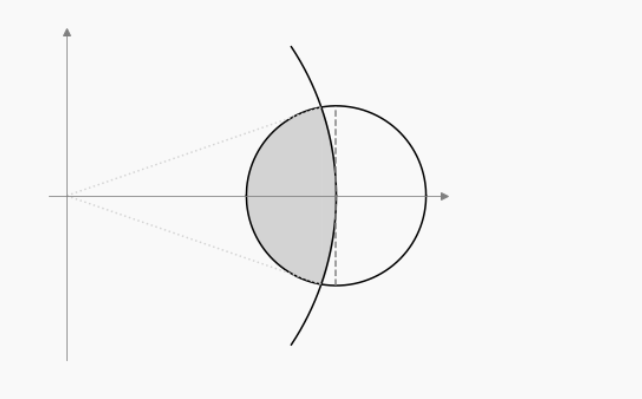

From Harris (2013): effects of J-S shrinkage

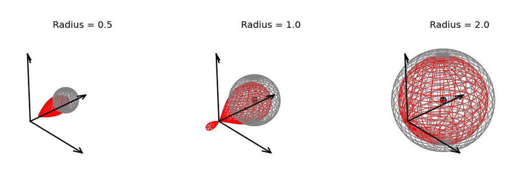

- van Houwelingen (2001) gives a very nice explanation/transition from James-Stein to penalized regression etc.

## From ridge to mixed models

i.e. treat this as an *empirical Bayesian* problem (we estimate the $\boldsymbol \beta$ values, but do not put a prior on $\sigma^2$ or a hyperprior on $\sigma_g^2$ (= $1/\lambda$)

From van Houwelingen (2001) (ultimately from Efron and Morris 1972):

If we use a prior with $\mu_i \sim N(\mu, \tau^2)$ (assuming residual variance is 1 wlog), then

$$\begin{split}
E(\mu_i|X_i) & = \mu + \frac{\tau^2}{\tau^2+1}(X_i - \mu) \\
\textrm{Var}(\mu_i|X_i) & = \frac{\tau^2}{\tau^2+1}
\end{split}$$

But we still have to estimate $\tau$ (or $\tau^2/(\tau^2+1)$) from the data.

## MVN version

We can be much more general:

$$\begin{split}
\mathbf y& \sim \textrm{Normal}({\mathbf X}\beta, \sigma^2) \\
\boldsymbol \beta& \sim \textrm{MVN}(\mathbf 0, \sigma_g^2 \mathbf I)
\end{split}$$

## Back to 1D

The simplest case (described in an R formula as `y ~ 1 + (1|g)`) is a model with a population-level intercept $\beta_0$ and group-level deviations from the population mean $b_i$.

This case, and more complex cases, can be written as

$$\begin{split}
y_i & \sim \textrm{Normal}(({\mathbf X}\boldsymbol \beta+ \mathbf Z\mathbf b)_i, \sigma^2_r) \\
\mathbf b& \sim \textrm{MVN}(\mathbf 0, \Sigma(\boldsymbol \theta))
\end{split}$$
where $\boldsymbol \theta$ is a vector of parameters that defines the covariance matrix $\Sigma$.

## How do we estimate this?

- expectation-maximization (EM) algorithm (e.g. see [here](https://stt.msu.edu/users/pszhong/Lecture_23_Spring_2017.pdf), or the [lmm package](https://github.com/jinghuazhao/R/tree/master/lmm))
- Or by linear algebra. For LMMs, we do a more complicated version of *data augmentation*.
- given a value for the random-effects variance, we can calculate the log-likelihood in one step (Bates et al. 2015)
- large, sparse matrix computation
- has to be done *repeatedly*
- most efficient if we analyze the matrix and permute to optimize structure (Bates et al. 2015)
- then we need to do some kind of search over the space of variances
- derivatives are available in particular special cases

## The general case

Given a model of the form

$$\begin{split}
y_i & \sim \textrm{Normal}(({\mathbf X}\boldsymbol \beta+ \mathbf Z\mathbf b)_i, \sigma^2_r) \\
\mathbf b& \sim \textrm{MVN}(\mathbf 0, \Sigma(\boldsymbol \theta))
\end{split}$$

- How do we specify and set up $Z$?
- How do we specify and set up $\Sigma$?

## constructing the random-effects model matrix

- specify as `(t|g)`; `t` is the *term* and `g` is the *grouping factor*
- for intercepts, just the indicator matrix
- for more complex models (random slopes), take the *Khatri-Rao* product of the model matrix of the term with the indicator matrix of `g`
- concatenate multiple random effects terms into a single `Z` matrix

## constructing the covariance matrix

- blockwise
- what’s the best way to parameterize a positive-(semi)definite matrix? (Pinheiro and Bates 1996)
- Cholesky decomposition:
  - scaled or unscaled?
  - Cholesky or log-Cholesky scale?
  - separating correlation and SD vectors: [glmmTMB](https://glmmtmb.github.io/glmmTMB/articles/covstruct.html#unstructured):

$$\Sigma = D^{-1/2} L L^\top D^{-1/2}, \quad D = \textrm{diag}(L L^\top)$$

## Key references

- Hastie, Tibshirani, and Friedman (2009) for ridge/lasso/elastic net
- Bates et al. (2015) for linear algebra underlying LMMs; incomplete MS on GLMM implementation [here](https://github.com/bbolker/asaglmm/blob/master/papers/glmer.pdf)
- van Houwelingen (2001) for the connections between James-Stein, ridge and other penalties, and mixed models

## References

Antognini, Joe. 2021. “Understanding Stein’s Paradox.” https://joe-antognini.github.io/machine-learning/steins-paradox.

Barber, Rina Foygel, Emmanuel J. Candès, Aaditya Ramdas, and Ryan J. Tibshirani. 2021. “Predictive Inference with the Jackknife+.” *The Annals of Statistics* 49 (1): 486–507. https://doi.org/10.1214/20-AOS1965.

Bates, Douglas, Martin Mächler, Ben Bolker, and Steve Walker. 2015. “Fitting Linear Mixed-Effects Models Using Lme4.” *Journal of Statistical Software* 67 (October): 1–48. https://doi.org/10.18637/jss.v067.i01.

Friedman, Jerome H., Trevor Hastie, and Rob Tibshirani. 2010. “Regularization Paths for Generalized Linear Models via Coordinate Descent.” *Journal of Statistical Software* 33 (February): 1–22. https://doi.org/10.18637/jss.v033.i01.

Harris, Naftali. 2013. “Visualizing the James-Stein Estimator.” https://www.naftaliharris.com/blog/steinviz/.

Hastie, Trevor, Robert Tibshirani, and J. H Friedman. 2009. *The Elements of Statistical Learning: Data Mining, Inference, and Prediction*. New York: Springer. https://hastie.su.domains/Papers/ESLII.pdf.

James, Gareth, Daniela Witten, Trevor Hastie, and Robert Tibshirani. 2013. *An Introduction to Statistical Learning*. Springer.

Obenchain, R. L. 1977. “Classical F-Tests and Confidence Regions for Ridge Regression.” *Technometrics* 19 (4): 429–39. https://doi.org/10.1080/00401706.1977.10489582.

Pinheiro, José C., and Douglas M. Bates. 1996. “Unconstrained Parametrizations for Variance-Covariance Matrices.” *Statistics and Computing* 6 (3): 289–96. https://doi.org/10.1007/BF00140873.

Roberts, David R., Volker Bahn, Simone Ciuti, Mark S. Boyce, Jane Elith, Gurutzeta Guillera-Arroita, Severin Hauenstein, et al. 2017. “Cross-Validation Strategies for Data with Temporal, Spatial, Hierarchical, or Phylogenetic Structure.” *Ecography* 40 (8): 913–29. https://doi.org/10.1111/ecog.02881.

van Houwelingen, J. C. 2001. “Shrinkage and Penalized Likelihood as Methods to Improve Predictive Accuracy.” *Statistica Neerlandica* 55 (1): 17–34. https://doi.org/10.1111/1467-9574.00154.

Wenger, Seth J., and Julian D. Olden. 2012. “Assessing Transferability of Ecological Models: An Underappreciated Aspect of Statistical Validation.” *Methods in Ecology and Evolution* 3 (2): 260–67. https://doi.org/10.1111/j.2041-210X.2011.00170.x.